# Creativity ratings of football actions: JRT results in brief

# 2. Agreement and reliability

Different indices answer different questions, which is why their values differ so much.

Table 5: Agreement and reliability indices.

| Index | Answers | Value | Note |
| --- | --- | --- | --- |
| Krippendorff’s α | Do two raters give the same rating to an action? | .395 | no bootstrap in this run |
| Cronbach’s α, crossed block | How consistent is the plain mean of 3 raters? (the largest set of ≥ 3 raters who all rated the same actions) | .750 | 95% CI [0.686, 0.799] (bootstrap, 1,000 replications) |
| GRM, actual scores | How reliable are the scores we actually have? (main value) | .684 | 95% CI [0.665, 0.698] (200 parameter draws) |
| GRM, at least 4 ratings per action (simulated) | How reliable would our scores be if every action had at least 4 ratings? | .833 | 95% range [.829, .837] over 50 simulations; 7,201 ratings added to 3,168 actions |
| GRM, full panel (hypothetical) | How reliable would scores be if all 24 raters rated every action? | .968 | 95% CI [0.964, 0.972] (200 parameter draws) |
| GRM, median per action | Reliability of a typical single action’s score | .706 | first quartile 0.592, third quartile 0.786 |

**Reading:** Raters agree only modestly on *individual* ratings (α = .395). Combining several ratings in the model gives usable scores (.684). If every action had at least 4 ratings, reliability would rise to .833 (simulation). This keeps the actual raters and adds 7,201 ratings by randomly drawn raters to the 3,168 actions with fewer than 4. The same simulation run on the actual design gives .682, close to the observed .684. A full panel (all 24 raters rate every action) would reach .968, but that design is far from ours.

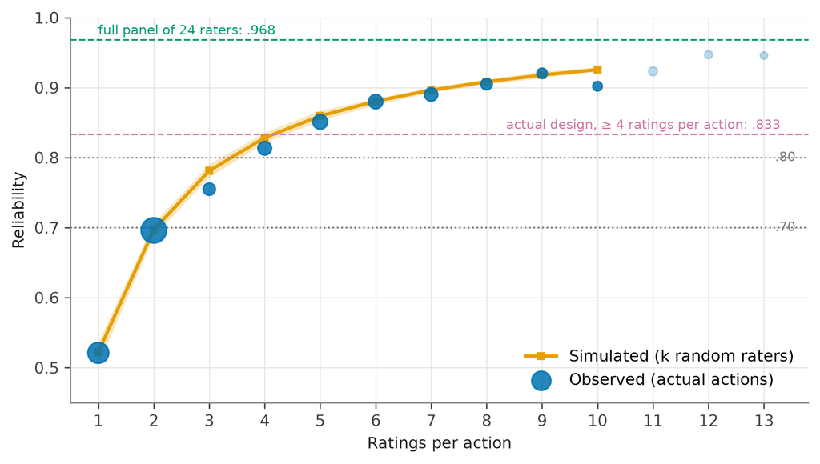

Figure 3: Reliability by number of ratings per action. Dots: observed mean rel_post of the actual actions with that many ratings (dot size = number of actions; faded = fewer than 10 actions). Line and band: model-based simulation (mean and 95% range over 50 replications). For each k, 2,000 simulated actions with creativity drawn from a standard normal distribution each receive exactly k ratings. The k raters are drawn at random from the 24 raters, all with equal probability, regardless of how many ratings each rater gave in reality. Ratings are generated from the fitted GRM and scored with it. The simulated curve therefore does not use our distribution of ratings per action (Figure 1); the observed dots do. Pink dashed line: actual design with every action topped up to at least 4 ratings.

Table 6: Reliability by number of ratings (observed vs simulated).

| Ratings per action | Actions observed | Observed mean rel_post | Simulated reliability [95% range] |
| --- | --- | --- | --- |
| 1 | 935 | .521 | .522 [.504, .536] |
| 2 | 2,163 | .696 | .697 [.688, .706] |
| 3 | 70 | .755 | .781 [.772, .790] |
| 4 | 128 | .813 | .828 [.821, .836] |
| 5 | 179 | .851 | .860 [.853, .867] |
| 6 | 158 | .880 | .881 [.875, .884] |
| 7 | 108 | .890 | .896 [.893, .900] |
| 8 | 47 | .905 | .908 [.904, .912] |
| 9 | 25 | .920 | .918 [.914, .923] |
| 10 | 14 | .902 | .926 [.923, .929] |

# 3. Rater tendencies

## Leniency and strictness

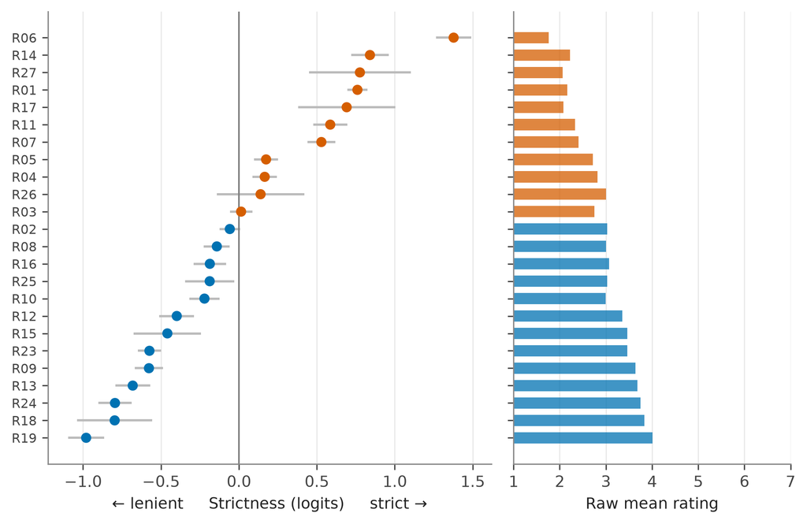

Figure 4: Left: rater strictness from the rating-scale MFRM (M1), with 95% intervals; 0 = average rater, higher = stricter. Right: the rater’s raw mean rating (1–7). Raters sorted by strictness.

Strictness spans 2.36 logits from the most lenient (R19, mean rating 4.01) to the strictest rater (R06, mean 1.76). M1 summarises strictness in one number per rater. The GRM thresholds show the same pattern in more detail.

## Use of the scale

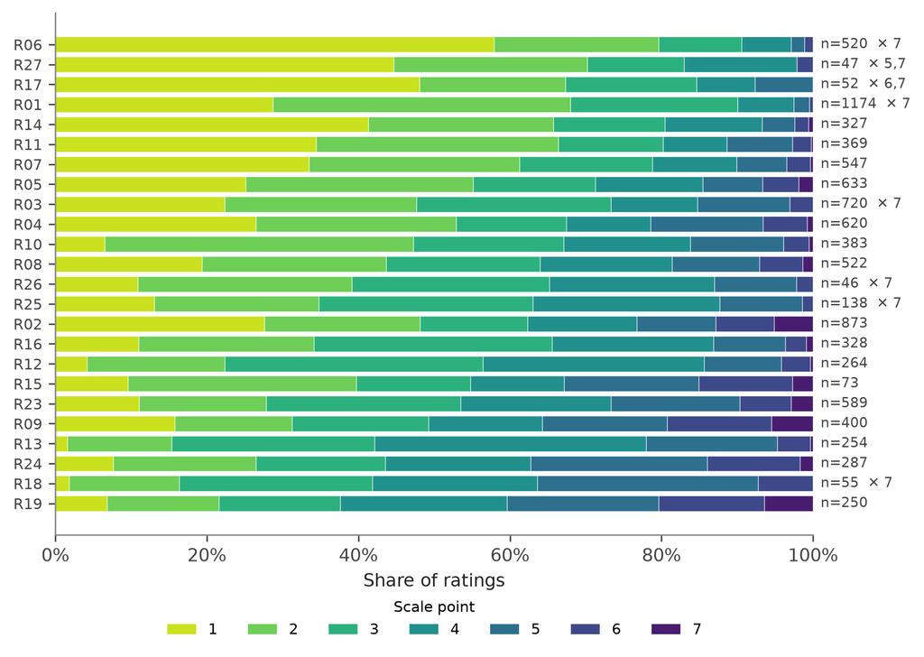

Figure 5: How often each rater used each scale point (share of their ratings). Sorted by mean rating; n = number of ratings. ✕ = scale point never used.

8 of 24 raters never used at least one scale point; in every case this included the top category (7). Floor use varies widely: R06 gave a “1” in 58% of ratings, others rarely did.